# I Contexte

# VII Analyse sur l'ensemble des pays

## Classement des pays

A l'exception des pays écartés pour raisons contextuelles (Chine et Russie )

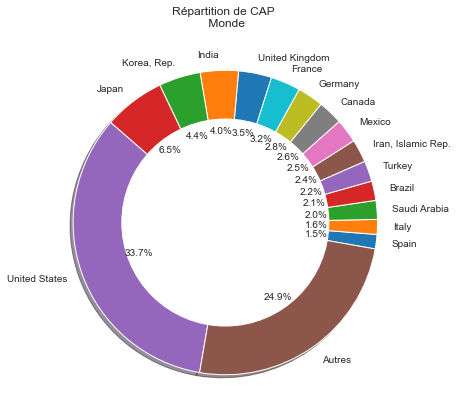

```python
S=DataSet['CAP'].drop(['China','Russian Federation']).sort_values(ascending=True)
Pie_Autres(S,titre='Répartition de CAP \n Monde',bar=False,part=1.4,size=(7,7))
```

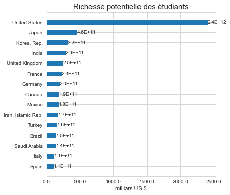

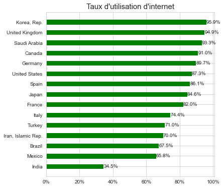

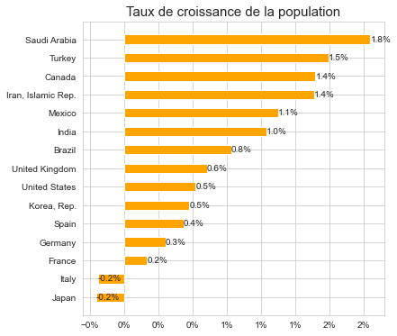

```python
#masque permettant de retenir les noms des n premiers pays du pieplot
mask=DataSet.index.isin(S.iloc[-15:].index)
# Tracé de CAP
bar1(DataSet[mask].sort_values(by='CAP').iloc[:,0],titre='Richesse potentielle des étudiants',size=(6,6))
# Tracé du taux d'utilisation d'internet
bar2(DataSet[mask].sort_values(by='IT.NET.USER.P2').iloc[:,1],titre='Taux d\'utilisation d\'internet',color='green',size=(6,6))
# Tracé du taux de croissance de la population
bar2(DataSet[mask].sort_values(by='SP.POP.GROW').iloc[:,2],titre='Taux de croissance de la population',color='orange',size=(6,6))
```

L'Inde a un taux d'utilisation d'internet trop peu élevés pour nous intéresser. L'Iran présente des risques politiques fort avec l'embargo américain.

Les pays ayant le plus fort potentiel sont les USA, la Corée, le Mexique, le Royaume Uni, la Turquie, l'Allemagne, le Brésil et le Canada.

## Les limites du modèle

- Pas de réél indicateur sur l'état des infrastructures réseau des pays, grosse différence entre juste avoir accès à du contenu et réseau stable avec bande passante suffisnte -> sur Data Bank utiliser d'autres études en complément.
- Ils y a un problème de données non homogènes sur leur dates d'obtentension -> obtenir les indices directement auprès des organismes qui les compilent.
- Faire une étude plus aprofondie des inégalités de richesses par pays pour mieux voir la part de PIB allouée aux 15 29 ans scolarisés
- Mon indicateur composite est impacté par la pyramide des âges, à PIB par habitant égaux il sera plus faible dans une population vieille, mais les + 29 ans auront plus de myens de financer les études de leurs descendants.